# IMAGE CLASSIFICATION

### 박수민, 082219

### dataset: [Caltech 101](http://www.vision.caltech.edu/Image_Datasets/Caltech101/)

### transfer learning: InceptionV3(GoogLeNet), pretrained weights on [Imagenet](http://www.image-net.org/)

### reference: github @bhavul의 [Caltech101 Object Classification](https://github.com/bhavul/Caltech-101-Object-Classification)

#### Inception 모델에 대한 설명은 [데이터사이언스스쿨 페이지](https://datascienceschool.net/view-notebook/8d34d65bcced42ef84996b5d56321ba9/)를 참고

```python
from keras.preprocessing import image
from glob import glob
import cv2, os, random
import numpy as np
import pandas as pd
import matplotlib.pyplot as plt
from tensorflow.keras.models import Sequential
from tensorflow.keras.layers import Dense, Flatten, Dropout,  GlobalAveragePooling2D
from tensorflow.keras.optimizers import Adam, Adadelta
from tensorflow.keras.utils import to_categorical
from tensorflow.keras.callbacks import ModelCheckpoint, EarlyStopping
%matplotlib inline

import os
import shutil
import keras
import tensorflow.keras
from tensorflow.keras import layers, Model
from tensorflow.keras.preprocessing.image import ImageDataGenerator
from tensorflow.keras.applications import inception_v3
from tensorflow.keras.applications.inception_v3 import InceptionV3
from tensorflow.keras.applications.inception_v3 import preprocess_input as inception_v3_preprocessor

from sklearn.model_selection import train_test_split
from sklearn.preprocessing import LabelEncoder
```

## 01. 이미지 전처리

- 다운받은 Caltech101데이터가 카테고리별 폴더로 나뉘어있으며 각 이미지는 labeling되지 않고 단순히 image (01).jpg등의 형식으로 정리되어있음.
- 각 카테고리의 이름을 붙여 accordian_1, faces_1, motorcycle_1 등으로 rename한다.
- 101_total 이라는 새로운 directory를 생성한뒤 102개(후에 Google Background 카테고리 제외하여 결과적으로는 101개 카테고리)의 각 카테고리별 데이터를 카피 저장한다.
- 별도로 label_list에 저장된 이름을 사용하여 101개 카테고리별 이미지데이터 resize하여 X_arrays에 0~100번 array로 넣고 Y_arrays에는 label들을 저장한다.
- sanity check를 실시한다.

```python
# for i in range(0, n_dirs) :
#     dir_name = directories[i]
#     path = os.path.join(data_path, dir_name) + "/"
#     os.chdir(path)
#     n = 0
#     print(dir_name)
#     for img in os.listdir(os.getcwd()):
#         new_name = dir_name+"_"+str(n)+".jpg"
#         os.rename(img, new_name)
#         n += 1
```

```python
# os.chdir(data_path)
# os.mkdir("101_total")
```

```python
#dest = data_path + "101_total/"
# for i in range(0, n_labels) :
#     path = os.path.join(data_path, directories[i])
#     os.chdir(path)
#     print(directories[i])
#     for img in os.listdir(path):
#          shutil.copy(img, dest )
```

```python
df_label = pd.read_csv("../input/label-list/label_list.csv")
labels = df_label.iloc[:,1]
```

```python
X_arrays = [[] for _ in range(len(labels)-1)]
Y_arrays = []
row, col = 96, 96
n_labels = 0
n_totdata = 0
n_Xarray = 0
for i in range(len(labels)):
    if labels[i] == 'BACKGROUND_Google':
        continue
    else:
        path = os.path.join("../input/caltech101/", labels[i])+"*"
        print(n_labels+1, path)
        arr = X_arrays[n_Xarray]
        n_catdata = 0
        for img in glob(path):
            if not img.endswith('.jpg'):
                # to escape hidden ipynb checkpoints and other unnecessary files
                continue
            x = cv2.imread(img)
            x = cv2.resize(x , (row,col))
            x = image.img_to_array(x)
            arr.append(x)
            Y_arrays.insert(n_totdata, labels[i])
            n_catdata +=1
            n_totdata +=1
        print("  ", labels[i],":", n_catdata,"of", n_totdata)
        n_labels +=1
        n_Xarray +=1
```

```
1 ../input/caltech101/accordion*
   accordion : 55 of 55
2 ../input/caltech101/airplanes*
   airplanes : 800 of 855
3 ../input/caltech101/anchor*
   anchor : 42 of 897
4 ../input/caltech101/ant*
   ant : 42 of 939
5 ../input/caltech101/barrel*
   barrel : 47 of 986
6 ../input/caltech101/bass*
   bass : 54 of 1040
7 ../input/caltech101/beaver*
   beaver : 46 of 1086
8 ../input/caltech101/binocular*
   binocular : 33 of 1119
9 ../input/caltech101/bonsai*
   bonsai : 128 of 1247
10 ../input/caltech101/brain*
   brain : 98 of 1345
11 ../input/caltech101/brontosaurus*
   brontosaurus : 43 of 1388
12 ../input/caltech101/buddha*
   buddha : 85 of 1473
13 ../input/caltech101/butterfly*
   butterfly : 91 of 1564
14 ../input/caltech101/camera*
   camera : 50 of 1614
15 ../input/caltech101/cannon*
   cannon : 43 of 1657
16 ../input/caltech101/car_side*
   car_side : 123 of 1780
17 ../input/caltech101/ceiling_fan*
   ceiling_fan : 47 of 1827
18 ../input/caltech101/cellphone*
   cellphone : 59 of 1886
19 ../input/caltech101/chair*
   chair : 62 of 1948
20 ../input/caltech101/chandelier*
   chandelier : 107 of 2055
```

[output cut: 147 more lines]

```
   umbrella : 75 of 8684
95 ../input/caltech101/watch*
   watch : 239 of 8923
96 ../input/caltech101/water_lilly*
   water_lilly : 37 of 8960
97 ../input/caltech101/wheelchair*
   wheelchair : 59 of 9019
98 ../input/caltech101/wild_cat*
   wild_cat : 34 of 9053
99 ../input/caltech101/windsor_chair*
   windsor_chair : 56 of 9109
100 ../input/caltech101/wrench*
   wrench : 39 of 9148
101 ../input/caltech101/yin_yang*
   yin_yang : 60 of 9208
```

Sanity Check (데이터 확인과정)

- X_arrays 의 총 개수는 101 개로 101 카테고리와 일치하며 accordian 의 raw data 는 총 55개로, X_arrays[0] 의 데이터 길이와 같다고 확인된다.

```python
print(len(X_arrays), len(X_arrays[0]))
```

```
101 55
```

- 위의 과정에 의하면 accordian 이미지일 X_arrays[0]에서 랜덤한 5개 이미지를 선정하여 plot한다.

[figure not shown]

```python
plt.figure(figsize=(12,8))
for i in range(5):
    plt.subplot(1, 5, i+1)
    img = image.array_to_img(random.choice(X_arrays[0]))
    plt.imshow(img, cmap=plt.get_cmap())

    plt.axis('off')

plt.show()
```

- string 형태의 label들을 encode하여 정수로 바꾼 Y_encoded에서 첫번째 값으로 등장한 '4'를 inverse_transform하여 0번 카테고리 이름인 accordian과 일치하는지 확인한다.

```python
label_encoder = LabelEncoder()
Y_encoded = label_encoder.fit_transform(Y_arrays)
label_encoder.inverse_transform([4])
```

```
array(['accordion'], dtype='<U15')
```

## 02. 데이터 전처리

- X, Y integer 전환 및 model에 사용할 수 있는 shape인지 확인
- train, test 데이터셋 생성

```python
Xs = np.array(X_arrays[0]).astype('float32') / 255
Y_encoded = np.asarray(Y_encoded).astype("int32")
for i in range(1,n_labels):
    x = np.array(X_arrays[i]).astype("float32") / 255
    Xs  = np.concatenate((Xs, x), axis=0)
```

```python
Xs.shape
```

```
(9208, 96, 96, 3)
```

```python
Y_encoded.shape
```

```
(9208,)
```

```python
seed = 0
np.random.seed(seed)
tensorflow.set_random_seed(seed)

X_train, X_test, Y_train, Y_test \
    = train_test_split(Xs, Y_encoded, test_size=0.25, random_state=seed)
```

```python
print(X_train.shape, Y_train.shape)
print(X_test.shape,Y_test.shape)
```

```
(6906, 96, 96, 3) (6906,)
(2302, 96, 96, 3) (2302,)
```

sanity check

- X_train 의 index = 1000 이미지를 plot하고 Y_encoded 로 인코딩된 y값을 구한 후 본래 label이름을 구하여 비교한다.

```
['Motorbikes']
```

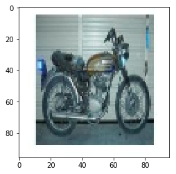

```python
plt.imshow(X_train[1000])
n = Y_train[1000]
print(label_encoder.inverse_transform([n]))
```

## 03. Model compilation

```python
inception_model \
= inception_v3.InceptionV3(include_top=False,
                           weights = "imagenet",
                           input_shape = (96,96,3))
```

```
Downloading data from https://github.com/fchollet/deep-learning-models/releases/download/v0.5/inception_v3_weights_tf_dim_ordering_tf_kernels_notop.h5
```

```python
inception_model.summary()
```

```
Model: "inception_v3"
__________________________________________________________________________________________________
Layer (type)                    Output Shape         Param #     Connected to
==================================================================================================
input_1 (InputLayer)            [(None, 96, 96, 3)]  0
__________________________________________________________________________________________________
conv2d (Conv2D)                 (None, 47, 47, 32)   864         input_1[0][0]
__________________________________________________________________________________________________
batch_normalization (BatchNorma (None, 47, 47, 32)   96          conv2d[0][0]
__________________________________________________________________________________________________
activation (Activation)         (None, 47, 47, 32)   0           batch_normalization[0][0]
__________________________________________________________________________________________________
conv2d_1 (Conv2D)               (None, 45, 45, 32)   9216        activation[0][0]
__________________________________________________________________________________________________
batch_normalization_1 (BatchNor (None, 45, 45, 32)   96          conv2d_1[0][0]
__________________________________________________________________________________________________
activation_1 (Activation)       (None, 45, 45, 32)   0           batch_normalization_1[0][0]
__________________________________________________________________________________________________
conv2d_2 (Conv2D)               (None, 45, 45, 64)   18432       activation_1[0][0]
__________________________________________________________________________________________________
batch_normalization_2 (BatchNor (None, 45, 45, 64)   192         conv2d_2[0][0]
__________________________________________________________________________________________________
activation_2 (Activation)       (None, 45, 45, 64)   0           batch_normalization_2[0][0]
__________________________________________________________________________________________________
max_pooling2d (MaxPooling2D)    (None, 22, 22, 64)   0           activation_2[0][0]
__________________________________________________________________________________________________
conv2d_3 (Conv2D)               (None, 22, 22, 80)   5120        max_pooling2d[0][0]
__________________________________________________________________________________________________
batch_normalization_3 (BatchNor (None, 22, 22, 80)   240         conv2d_3[0][0]
__________________________________________________________________________________________________
activation_3 (Activation)       (None, 22, 22, 80)   0           batch_normalization_3[0][0]
__________________________________________________________________________________________________
conv2d_4 (Conv2D)               (None, 20, 20, 192)  138240      activation_3[0][0]
__________________________________________________________________________________________________
batch_normalization_4 (BatchNor (None, 20, 20, 192)  576         conv2d_4[0][0]
__________________________________________________________________________________________________
activation_4 (Activation)       (None, 20, 20, 192)  0           batch_normalization_4[0][0]
__________________________________________________________________________________________________
max_pooling2d_1 (MaxPooling2D)  (None, 9, 9, 192)    0           activation_4[0][0]
__________________________________________________________________________________________________
```

[output cut: 610 more lines]

```
__________________________________________________________________________________________________
concatenate_1 (Concatenate)     (None, 1, 1, 768)    0           activation_91[0][0]
                                                                 activation_92[0][0]
__________________________________________________________________________________________________
activation_93 (Activation)      (None, 1, 1, 192)    0           batch_normalization_93[0][0]
__________________________________________________________________________________________________
mixed10 (Concatenate)           (None, 1, 1, 2048)   0           activation_85[0][0]
                                                                 mixed9_1[0][0]
                                                                 concatenate_1[0][0]
                                                                 activation_93[0][0]
==================================================================================================
Total params: 21,802,784
Trainable params: 21,768,352
Non-trainable params: 34,432
__________________________________________________________________________________________________
```

```python
for layer in inception_model.layers:
     layer.trainable = False
```

```python
_input = inception_model.get_layer(index = 0).input
_output = inception_model.output
print(_input)
print(_output)
```

```
Tensor("input_1:0", shape=(?, 96, 96, 3), dtype=float32)
Tensor("mixed10/concat:0", shape=(?, 1, 1, 2048), dtype=float32)
```

```python
x = _output
x = GlobalAveragePooling2D()(x)
x = Dense(1024, activation='relu')(x)
x = Dropout(0.4)(x)
x = Dense(512, activation='relu')(x)
x = Dropout(0.4)(x)
predictions = Dense(n_labels, activation='softmax')(x)
```

```python
model = Model (_input, predictions)
model.summary()
```

```
Model: "model"
__________________________________________________________________________________________________
Layer (type)                    Output Shape         Param #     Connected to
==================================================================================================
input_1 (InputLayer)            [(None, 96, 96, 3)]  0
__________________________________________________________________________________________________
conv2d (Conv2D)                 (None, 47, 47, 32)   864         input_1[0][0]
__________________________________________________________________________________________________
batch_normalization (BatchNorma (None, 47, 47, 32)   96          conv2d[0][0]
__________________________________________________________________________________________________
activation (Activation)         (None, 47, 47, 32)   0           batch_normalization[0][0]
__________________________________________________________________________________________________
conv2d_1 (Conv2D)               (None, 45, 45, 32)   9216        activation[0][0]
__________________________________________________________________________________________________
batch_normalization_1 (BatchNor (None, 45, 45, 32)   96          conv2d_1[0][0]
__________________________________________________________________________________________________
activation_1 (Activation)       (None, 45, 45, 32)   0           batch_normalization_1[0][0]
__________________________________________________________________________________________________
conv2d_2 (Conv2D)               (None, 45, 45, 64)   18432       activation_1[0][0]
__________________________________________________________________________________________________
batch_normalization_2 (BatchNor (None, 45, 45, 64)   192         conv2d_2[0][0]
__________________________________________________________________________________________________
activation_2 (Activation)       (None, 45, 45, 64)   0           batch_normalization_2[0][0]
__________________________________________________________________________________________________
max_pooling2d (MaxPooling2D)    (None, 22, 22, 64)   0           activation_2[0][0]
__________________________________________________________________________________________________
conv2d_3 (Conv2D)               (None, 22, 22, 80)   5120        max_pooling2d[0][0]
__________________________________________________________________________________________________
batch_normalization_3 (BatchNor (None, 22, 22, 80)   240         conv2d_3[0][0]
__________________________________________________________________________________________________
activation_3 (Activation)       (None, 22, 22, 80)   0           batch_normalization_3[0][0]
__________________________________________________________________________________________________
conv2d_4 (Conv2D)               (None, 20, 20, 192)  138240      activation_3[0][0]
__________________________________________________________________________________________________
batch_normalization_4 (BatchNor (None, 20, 20, 192)  576         conv2d_4[0][0]
__________________________________________________________________________________________________
activation_4 (Activation)       (None, 20, 20, 192)  0           batch_normalization_4[0][0]
__________________________________________________________________________________________________
max_pooling2d_1 (MaxPooling2D)  (None, 9, 9, 192)    0           activation_4[0][0]
__________________________________________________________________________________________________
```

[output cut: 622 more lines]

```
__________________________________________________________________________________________________
dense (Dense)                   (None, 1024)         2098176     global_average_pooling2d[0][0]
__________________________________________________________________________________________________
dropout (Dropout)               (None, 1024)         0           dense[0][0]
__________________________________________________________________________________________________
dense_1 (Dense)                 (None, 512)          524800      dropout[0][0]
__________________________________________________________________________________________________
dropout_1 (Dropout)             (None, 512)          0           dense_1[0][0]
__________________________________________________________________________________________________
dense_2 (Dense)                 (None, 101)          51813       dropout_1[0][0]
==================================================================================================
Total params: 24,477,573
Trainable params: 2,674,789
Non-trainable params: 21,802,784
__________________________________________________________________________________________________
```

```python
opt = Adadelta(lr=1.0, rho=0.9, epsilon=1e-08, decay=0.0)
model.compile(optimizer=opt,
              loss='sparse_categorical_crossentropy',
              metrics=['sparse_categorical_accuracy'])
```

```python
MODEL_DIR = "keras.model"
# if not os.path.exists(MODEL_DIR):
#     os.mkdir(MODEL_DIR)
# modelpath=MODEL_DIR + "{epoch:02d}-{val_loss:.4f}.hdf5"

checkpointer = ModelCheckpoint(filepath=MODEL_DIR,
                               monitor='val_loss',
                               verbose=1,
                               save_best_only=True,
                               mode = "min")
early_stopping_callback = EarlyStopping(monitor='val_loss',
                                        mode = "auto",
                                        patience=5)
```

## 04. Model running

```python
EPOCHS = 200
BS = 40

# construct the training image generator for data augmentation
aug = ImageDataGenerator(rotation_range=20, zoom_range=0.15,
    width_shift_range=0.2, height_shift_range=0.2, shear_range=0.15,
    horizontal_flip=True, fill_mode="nearest")

# train the network
history = model.fit_generator(aug.flow(X_train, Y_train, batch_size=BS),
                        validation_data=(X_test, Y_test),
                        steps_per_epoch=len(X_train) // BS,
                        epochs=EPOCHS)
```

```python
model.save_weights("keras.weights2")
```

```
 Test Accuracy: 0.4540
```

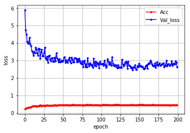

```python
print("\n Test Accuracy: %.4f" % (model.evaluate(X_test, Y_test)[1]))

y_acc = history.history['val_sparse_categorical_accuracy']
y_vloss = history.history['val_loss']

x_len = np.arange(len(y_vloss))
plt.plot(x_len, y_acc ,marker='.', c="red", label='Acc')
plt.plot(x_len, y_vloss , marker='.', c="blue", label='Val_loss')

plt.legend(loc='upper right')
plt.grid()
plt.xlabel('epoch')
plt.ylabel('loss')
plt.show()
```

현재까지의 결과는 test accuracy가 45%로 높지 않은 정확도를 보인다.  
그러나 참고한 github @bhavul의 [Caltech101 Object Classification](https://github.com/bhavul/Caltech-101-Object-Classification) 프로젝트에 따르면 해당 모델(현 프로젝트의 모델과 거의 일치 - loss함수 제외)은 각 카테고리별 accuracy로는 평균 97%까지 도달할 수 있는 것으로 나온다.  
참고 프로젝트의 데이터는 현 모델이 사용한 데이터의 전 버전으로 보이며 따라서 데이터에 약간의 차이가 날 수 있을 것으로 예상된다. 또한 현 모델을 train하는데 사용한 데이터의 정확도가 극히 일부만 확인되었으므로 후에 더 정밀한 확인절차가 필요할 것으로 보인다. 참고모델의 경우 loss함수가 categorical crossentropy인데 이 또한 sparse categorical crossentropy와 약간의 차이가 날 수 있으므로 추가적인 확인이 필요하다.

## to be continued

```python
# def find_accuracy_per_category(mymodel):
#     category_accuracy_dict = {}
#     for label in labels:
#         X_cat = []
#         Y_cat_test_1 = []
#         if label == 'BACKGROUND_Google':
#             continue
#         else:
#             path = os.path.join("../input/caltech101/", label)+"*"
#             print(label)
#             for img in glob(path):
#                 if not img.endswith('.jpg'):
#                     # to escape hidden ipynb checkpoints and other unnecessary files
#                     continue
#                 x = cv2.imread(img)
#                 x = cv2.resize(x , (row,col))
#                 x = image.img_to_array(x)
#                 X_cat.append(x)
#                 Y_cat_test_1.insert(n_totdata, labels[i])
#         Y_cat_test = label_encoder.transform(Y_cat_test_1)
#         X_cat_test = np.array(X_cat).astype("float32") / 255
#         score = mymodel.evaluate(x = X_cat_test, y = Y_cat_test, verbose = 1)
#         category_accuracy_dict[label] = score
#     print("Accuracy for each class")
#     return category_accuracy_dict
```